# Suburbanization in Poland

Katarzyna Goch

15 March 2019

This is the report for the final assignment from course “Analysis of Spatio-Temporal Data”, WS 2018/19.  
Supervisor: prof. Edzer Pebesma.

# Aim and scope of the study

Spatial planning in Poland faces several challenges. The far-reaching planning autonomy of basic local government units joined with the process of issuing building permits based on administrative decisions in case of a lack of the local spatial development plans results in excessive and development of built-up areas. Especially negative in this context is the phenomena of suburbanization, which “is a population shift from central urban areas into suburbs, resulting in the formation of (sub)urban sprawl” [Wikipedia](https://en.wikipedia.org/wiki/Suburbanization). The roots of the issue of suburbanization were briefly described in the report on the spatial planning determinants of cohesion policy implementation in Polish regions (Komornicki et al., 2019, in print): The current Spatial Planning and Land Development Act has been in force since 2003. The Act invalidated former local spatial development plans (adopted before 1994). Since only few municipalities managed to adopt the new plans after 1995, legislators decided to facilitate investments in the areas that were not covered by local spatial development plans. This was possible on the basis of “decision on land development or building permission for public purpose investment”. Coverage by local spatial development plans at the moment of passing the Act amounted to ca. 23%, and currently it is close to 30% of the Poland’s area.The undertaken solutions and the low coverage of binding planning documents resulted in a strong, deepening crisis concerning land management, including the high costs of servicing dispersed, chaotic settlement on the outskirts of cities. The aim of the project is to analyze spatiotemporal characteristics of population distribution in Poland in years 2002-2017 and to observe the distribution patterns. Moreover, the goal of the project is to observe the phenomena of suburbanization in the vicinity of the main Polish cities. In the following project the population data in NUTS 4 (counties) in years 2002-2017 will be analyzied. The borders of counties were obtained from the shapefile with counties borders. Data are available from Local Data Bank and National Official Register of Territorial Division of the Country:

- https://bdl.stat.gov.pl/BDL/start
- http://www.gugik.gov.pl/

**Hypothesis (H0) tested in this project states that there is no suburbanization effect taking place in the Polish counties**

**The alternative hypothesis (H1) suburbanization is a process occuring around the main Polish cities in the period 2002 - 2017. This means that the population in the cities themselves decrease, wheras the population in the adjacent counties insreseas.**

**The second alternative hypothesis (H2) tested in the project is that there can be suburbanization observed in the areas of the main Polish cities, however, not in all of them.**

# Methodology

Firstly, the data was collected and prepared for the further analysis.Data obtained provided absolute number of people leaving in cuntries. For the purpose of the study, the increase of population between the years was calculated. Secondly, the the population increase in Poland in years 2002 - 2017 was mapped and examined. The spatial correlation of population in counties was examined using Moran’s I Test. In the next step, the main cities with their adjacent counties (potential suburban ares) were selected (with population over 500 000 people) ([Szukalski, 2015](http://dspace.uni.lodz.pl/xmlui/bitstream/handle/11089/11164/2015-04%20Suburbanizacja.pdf?sequence=1&isAllowed=y)). Population increase in these areas was plotted and examined. Finally, spatial correlation in the cities and surrounding counties in the consecutive years were measured using Moran’s I Test.

# Collect and prepare data

Population data and polygon data were obtained from Local Data Bank and National Official Register of Territorial Division of the Country. Date of access: 3rd Jan 2019. https://bdl.stat.gov.pl/BDL/start http://www.gugik.gov.pl/

## Population data

Popularion data was obtained from BDL on the 07/01/2019.

[figure not shown]

## Loading population datatset

The population data used in the projects shown disturbing values for years 2009-2010. That was caused by the change of the methodology. According to National Office Register, population balance for years 2002-2009 was developed on the basis of the results of the 2002 National Census. The 2002 National census showed the population of Poland about 392 000 smaller in relation to the population balances at that time.Since 2010, the base of the balance of state and population structure is the results of the 2011 National Census Secondly, the population balance was prepared until 2009 for two categories of population residence: 1) actually residing, 2) registered for permanent residence. Since 2010, the population balance has been drawn up for one category of population. Balance data for the permanent and actual population as well as the ratios for 2010, the base of which was the data from the Census of 2002, are of historical value only. Therefore population data for 2010 and population increase in period 2009-2010 was excluded from the further analysis.

```r
# Load the data and check
pop_df <- read.csv2("LUDN_2002_2017_powiaty_csv.csv",
                header=TRUE,
                quote="\"",
                stringsAsFactors = FALSE,
                strip.white = TRUE)
# Drop last column (empty)
pop_df[19]<-NULL
# Chnage columns names
colnames(pop_df) <- c("kod","nazwa","2002","2003","2004","2005","2006","2007","2008","2009","2010","2011","2012","2013","2014","2015","2016","2017")
# Look at the dataset
#head(pop_df)
```

County “m. Wałbrzych” no 263000 was merged with county “powiat wałbrzyski” no 221000 after 2002 and seperated again in 2013. Therefore number of population from those counties was summed. The merged county has number 221000.The deleted counties were: * “Powiat m. Wałbrzych do 2002” (Wałbrzych city before 2002), no 263000 * “Powiat m. Wałbrzych po 2013” (Wałbrzych city after 2013), no 265000

```r
# <-------- Join two counties -------->
## First, NA values were changed into 0
pop_df[is.na(pop_df)]<-0
## Then values for "m. Wałbrzych" 263000 and "powiat wałbrzyski" 221000 were merged for into one "powiat wałbrzyski"
newrow <- pop_df[21,3:18] + pop_df[29,3:18] + pop_df[31,3:18]
pop_df[21,3:18] <- newrow
## Delete row 29 and 31
pop_df <- pop_df[-c(29,31), ]
```

In the project the increase of population in counties instead of the absolute population values was analyzed. The population increase $i$ in year $t$ was calculated on the basis of population $pop$ using equation:
$$i_{t}=\frac{pop_{t}-pop_{t-1}}{pop_{t-1}}$$

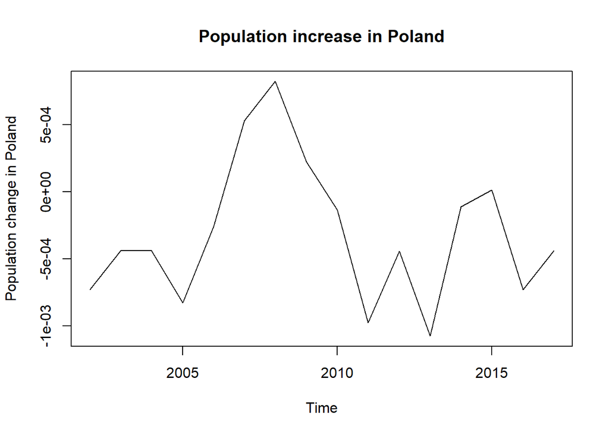

```r
# <-------- Store data for the total population -------- >
## Create df with the main cities
mainCities <- pop_df[pop_df$`2017`>500000,]
## Create df with the summary population
pop_cols<-names(pop_df)

# <-------- Population increase in Poland --------- >
pop_all <- pop_df
## Remove columns with name and code
pop_all["kod"]<-NULL
pop_all["nazwa"]<-NULL

pop_all_total <- as.matrix(colSums(pop_all))

## Calculate the population increase for the whole country
for (i in 1:17){
  pop_all_total[i+16]<-pop_all_total[i+1]-pop_all_total[i]
  pop_all_total[i+16]<-(pop_all_total[i+16]/pop_all_total[i])
}

## Remove old columns
pop_all_increase <- pop_all_total[17:31]

## Remove increse 2009-2010 due to the error in the data (changed methodology)
pop_all_increase <- pop_all_increase[which(pop_all_increase<0.009)]

pop_all_increase <- as.data.frame(pop_all_increase)
rownames(pop_all_increase)<-c("2003.1.all","2004.1.all","2005.1.all","2006.1.all","2007.1.all","2008.1.all","2009.1.all","2011.1.all","2012.1.all","2013.1.all","2014.1.all","2015.1.all","2016.1.all","2017.1.all")

## Create time series
pop_all_ts<-ts(pop_all_increase,start=2002, end=2017, frequency=1)

## Plot time series
ts.plot(pop_all_ts, main = "Population increase in Poland", ylab="Population change in Poland")
```

From the popluation increase plot in Poland it can be observed, that the population increase was varied, but in a vary small scale. Overall, it can be said that it was rather stable and slightly below zero. This means, that the total population of Poland was slowly decreasing over time.

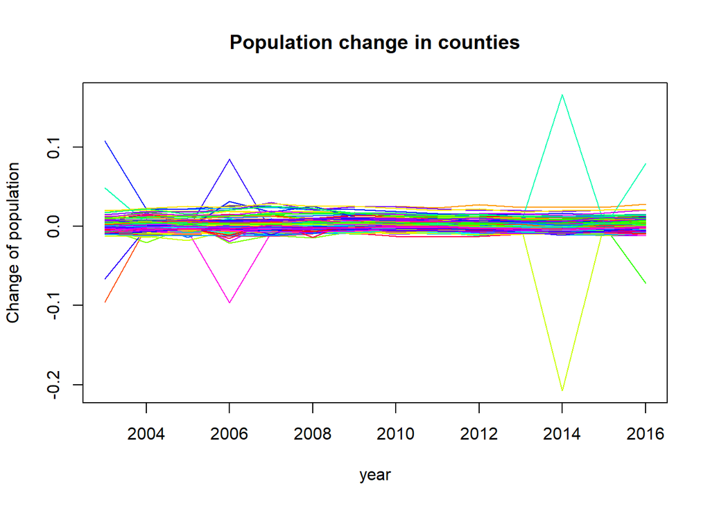

```r
# <-------- Calculate popultion increase in counties -------->
for (i in 3:17){
  pop_df[i+16]<-(pop_df[pop_cols[i+1]]-pop_df[pop_cols[i]])
  pop_df[i+16]<-(pop_df[i+16]/pop_df[pop_cols[i]])
}

# <-------- Simplify the data -------->
## Delete name and code and population
pop_df[2:18]<-NULL

# <-------- Create time series with population increase -------->
## Copy and simplify population data
pop_t<-pop_df
pop_t["kod"]<-NULL

# <-------- Data in 2010 were with an ERROR, thus 2009-2010 increase was deleted from the datatset -------->
pop_t["2010.1"]<-NULL
pop_t<-as.data.frame(t(pop_t))

## Create time series from the transpozed population data
pop_ts<-ts(pop_t, start=2003, end=2016, frequency=1)

# Plot time series
## Plot should be amended with the different scale and X asis
plot(pop_ts, plot.type="single", ylab="Change of population", xlab="year", col=rainbow(20), main="Population change in counties")
```

From the plot showing population change in countis it can be observed that the overall population change was around 0. Only a few counties shown differences significant, in relation to the whole country.

## Polygon data

Shapefile with counties borders was obtained from GUGIK on 03/01/2019.

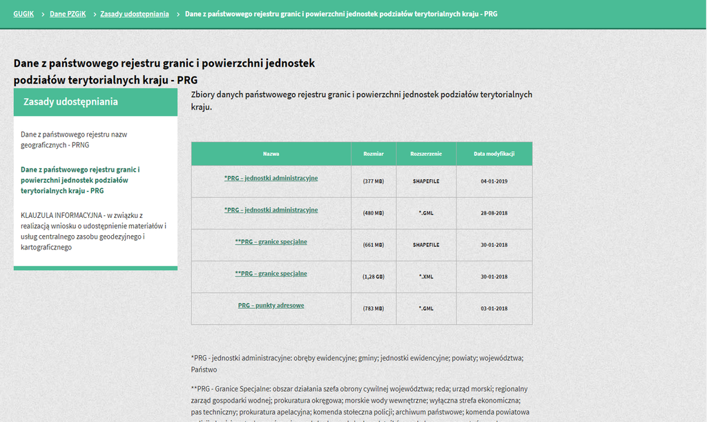

## Load polygon data

Polygon data was obtained as a shapefile. Data had ETRS89 Poland CS92 (EPSG: 2180) projected coordinate system assigned.

```r
## Load shp
counties <- readOGR("powiaty","powiaty")
counties <- spTransform(counties,CRS("+init=epsg:2180"))

counties@data$jpt_kod_je<-as.numeric(as.character(counties@data$jpt_kod_je))
counties_sf<- st_as_sf(counties)
```

Data for county “m. Wałbrzych” no 265 was summed with data for county “powiat wałbrzyski” no 221. Therefore these two polygons were merged as well. The merged county has number 221.

```r
# Merge two polygons
WalbrzychCity <- counties[counties$jpt_kod_je == 265,]
WalbrzychCity_sf<-st_as_sf(WalbrzychCity)

WalbrzychCounty <- counties[counties$jpt_kod_je == 221,]
WalbrzychCounty_sf<-st_as_sf(WalbrzychCounty)

# Union the polygons into a new county and set the number to 221
newcounty<-st_union(WalbrzychCity_sf,WalbrzychCounty_sf)
newcounty$jpt_kod_je<-221

# Join the new poygon with the rest of counties
## Substract all the counties, that are not Walbrzych or Walbrzych county
othercounties<-counties_sf[which(counties_sf$jpt_kod_je!=265 & counties_sf$jpt_kod_je!=221),]

## Combine it with the new county no 221
counties_sf$jpt_kod_je[counties_sf$jpt_kod_je == 265] = 221

##Drop useless columns
counties_sf[1:3]<-NULL
counties_sf[2:23]<-NULL
counties_sf[2:4]<-NULL
```

## Join population and polygon data

The population dataframe and the shapefile was joined using the codes of the units.

```r
# Merge counties polygons and population data
pop_df = mutate(pop_df, ID = as.numeric(kod)/1000)
counties_sf = mutate(counties_sf, ID = (as.numeric(jpt_kod_je)/1))
full_counties_with_2010 <- left_join(counties_sf, pop_df)
# Data for 2010 was deleted due to the errors
full_counties <- full_counties_with_2010
full_counties["2010.1"] <- NULL
```

# Map and examine population data in Poland

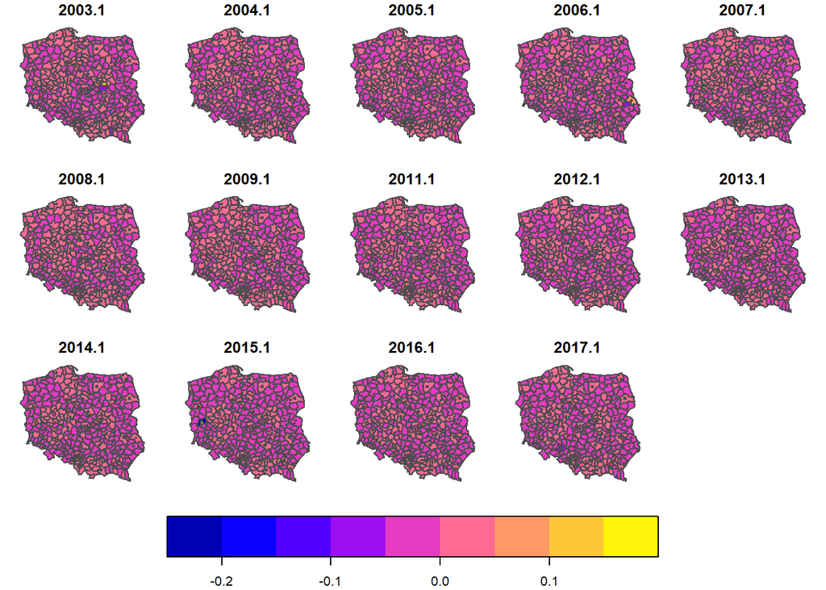

```r
# Plot the dataset
plot(full_counties[4:17], max.plot=15, border = grey(.3), key.pos=1, main = "Population increase in Polish counties 2002-2017")
```

From the maps it can be observed that some areas have constantly positive values of the population change, whereas othe areas have constantly negative values. This might inform about the ongoing process of depopulation of rural areas and movement of people towards urbanizaed areas.

## Spatial autocorrelation in the country scale

Data was examined for the existence of autocorrelation in the counties in 2017. The most frequently used method to assess autocorrelation is Morans I value [Spatiotemporal Analysis] (https://www.mailman.columbia.edu/research/population-health-methods/spatiotemporal-analysis) and this method is used in the assignment.

## Examine spatial autocorrelation

To perform the autocorrelation analysis, first the neighbourhood list had to be created. The neighbourhood list included one neighbour only.

```r
# Create neighbourhood
## Create centroids for the counties
counties_c<-coordinates(counties)
## Creating a list for 1 nearest neighbour
myNB1 <- knn2nb(knearneigh(counties_c,1,TRUE))
# Create list to store Moran test output
Poland_MI <- list()

# Execute Moran I Test
for (i in 4:17) {
  Poland_MI[[i-3]] <- capture.output(moran.test(na.omit(full_counties[[i]]), nb2listw(myNB1, style="B", zero.policy=TRUE), zero.policy=TRUE))
}
```

# Suburbanization

## Population trends in main cities and suburban zones

### Main cities

Cities with population over 500 000 people and their suburban zones (adjacent counties) were selected fo further analysis. In Poland these cities are:

- Wrocław
- Łódź
- Kraków
- Warszawa
- Poznań

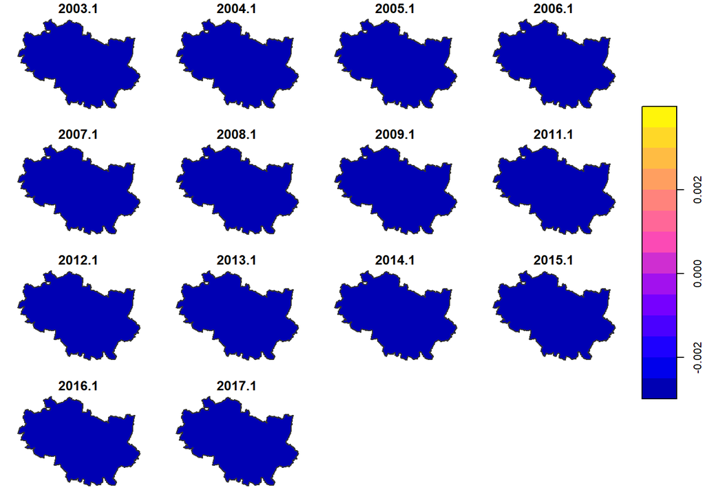

```r
# Prepare the code of the unit to be the same as ID in the counties
mainCities = mutate(mainCities, ID = as.numeric(kod)/1000)

# Select the main cities
city1 <- full_counties[full_counties$ID==mainCities$ID[1],]
city2 <- full_counties[full_counties$ID==mainCities$ID[2],]
city3 <- full_counties[full_counties$ID==mainCities$ID[3],]
city4 <- full_counties[full_counties$ID==mainCities$ID[4],]
city5 <- full_counties[full_counties$ID==mainCities$ID[5],]
# And bind them into one sf object
mainCitiesSet<-rbind(city1, city2, city3, city4, city5)
# Plot main cities separately for better visibility
plot(city1[4:17], main = "Wrocław", max.plot=15, border = grey(.2), key.pos=4)
```

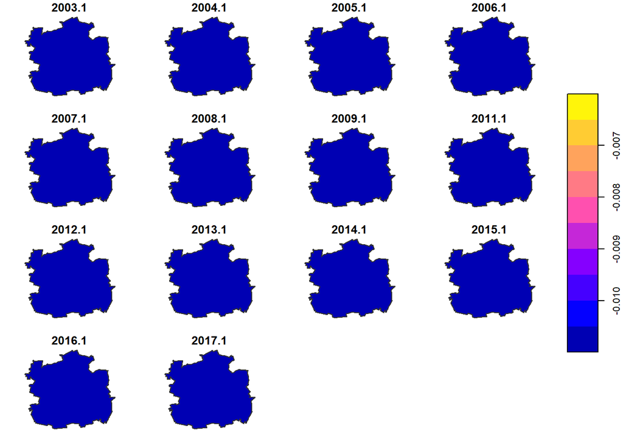

```r
plot(city2[4:17], main = "Łódź", max.plot=15, border = grey(.2), key.pos=4)
```

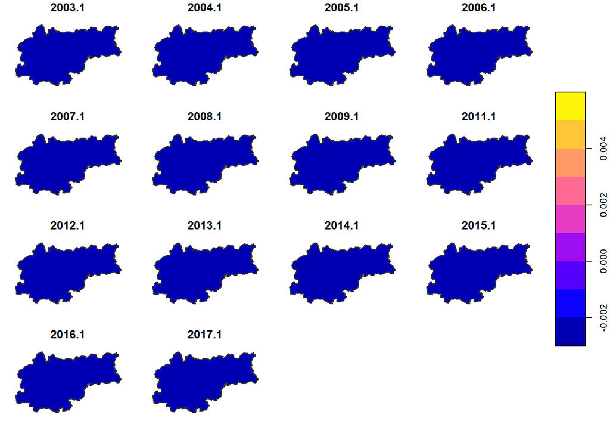

```r
plot(city3[4:17], main = "Kraków", max.plot=15, border = grey(.2), key.pos=4)
```

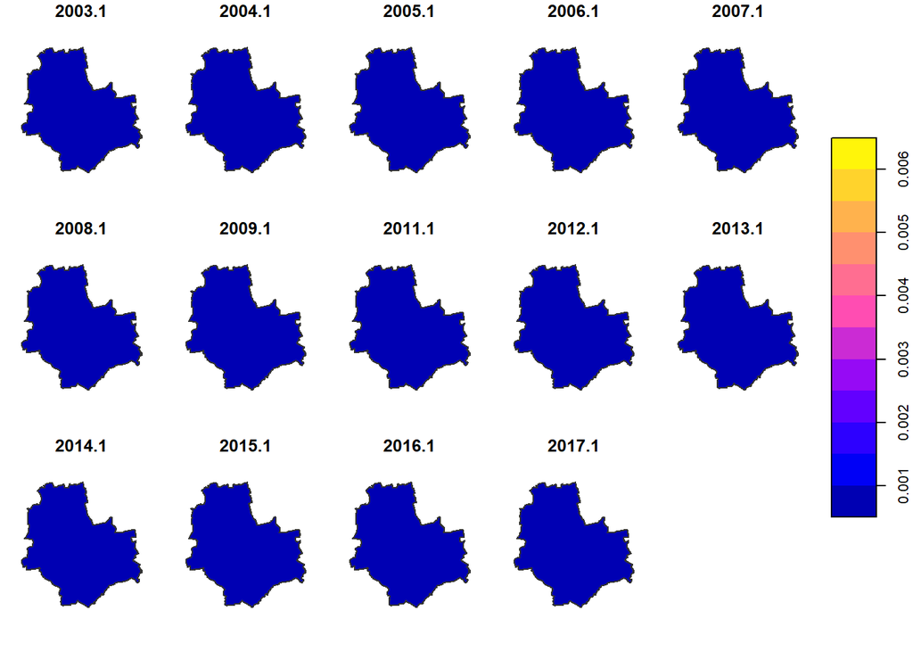

```r
plot(city4[4:17], main = "Warszawa", max.plot=15, border = grey(.2), key.pos=4)
```

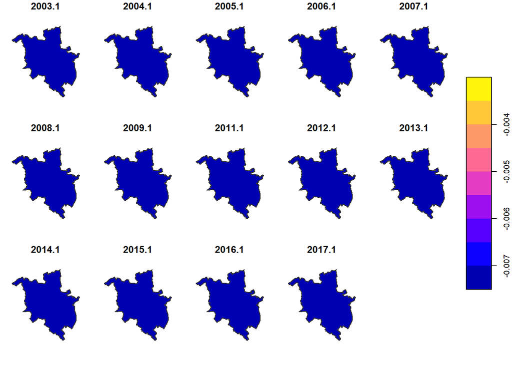

```r
plot(city5[4:17], main = "Poznań", max.plot=15, border = grey(.2), key.pos=4)
```

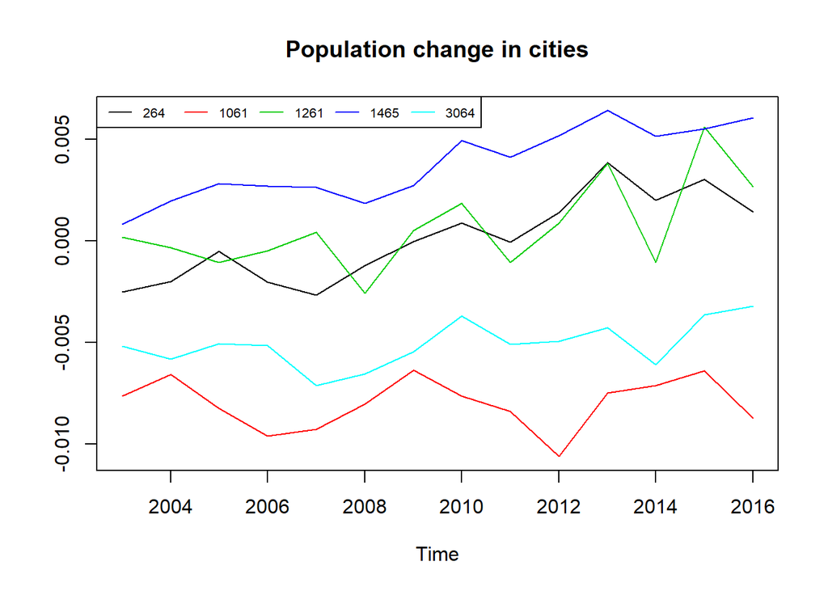

```r
# Extract data.frame from simple features objects
## ... for main cities
mainCitiesSet_t <- mainCitiesSet
st_geometry(mainCitiesSet_t) <- NULL
## Create dataframe with average population increase values for all main cties
mainCitiesSet_sum <- colSums(mainCitiesSet_t)
mainCitiesSet_av <-mainCitiesSet_sum/nrow(mainCitiesSet_t)
## Create time series with average population increase values for all main cties
cities_av_ts <- ts(mainCitiesSet_av[4:17], start = 2003, end = 2016, frequency = 1)

## Simplify and transpoze data to create ts
mainCitiesSet_t["jpt_kod_je"]<-NULL
mainCitiesSet_t["kod"]<-NULL
mainCitiesSet_t["ID"]-> c_names
mainCitiesSet_t["ID"]<- NULL
mainCitiesSet_t <- as.data.frame(t(mainCitiesSet_t))

### Create time-series
city_ts<-ts(mainCitiesSet_t, start=2003, end=2016, frequency=1, names = unlist(c_names, use.names=FALSE))

ts.plot(city_ts, main = "Population change in cities", col = 1:ncol(city_ts))
legend("topleft", colnames(city_ts), col = 1:ncol(city_ts), lty=1, cex=.65, ncol=5)
```

The biggest population increase was observed in Warsaw (city code 1465). Warsaw is the capital city of Poland and is a tempting place to live for many Polish people.The increse in years 2002-2017 varied from orun 0% in the beginning of this period up to aroun 0,5% in 2017. The city wit the biggest population decrease was Łódź (city code 1061). The annual decrease of population baried between 0,5% to 1% in each year.

### Suburban zones

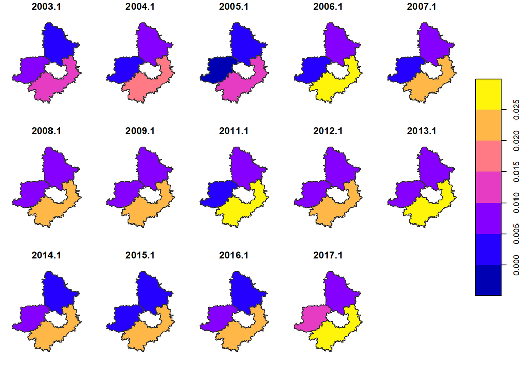

```r
# Select the suburban zones

# Find the adjacent polygons to the main cities
suburb1 <- full_counties[st_intersects(x = full_counties, y = city1, sparse = FALSE),] # Wrocław
suburb2 <- full_counties[st_intersects(x = full_counties, y = city2, sparse = FALSE),] # Łódź
suburb3 <- full_counties[st_intersects(x = full_counties, y = city3, sparse = FALSE),] # Kraków
suburb4 <- full_counties[st_intersects(x = full_counties, y = city4, sparse = FALSE),] # Warszawa
suburb5 <- full_counties[st_intersects(x = full_counties, y = city5, sparse = FALSE),] # Poznań

suburbSet <- rbind(suburb1, suburb2, suburb3, suburb4, suburb5)
# Disjoint the main cities from the set of suburban counties
## Create centroids of the main cities
city1centroid <- st_centroid(st_union(city1))
city2centroid <- st_centroid(st_union(city2))
city3centroid <- st_centroid(st_union(city3))
city4centroid <- st_centroid(st_union(city4))
city5centroid <- st_centroid(st_union(city5))

## Disjoint the main cities in each region
newSuburb1 <- suburb1[st_disjoint(x = suburb1, y = city1centroid, sparse = FALSE),]
newSuburb2 <- suburb2[st_disjoint(x = suburb2, y = city2centroid, sparse = FALSE),]
newSuburb3 <- suburb3[st_disjoint(x = suburb3, y = city3centroid, sparse = FALSE),]
newSuburb4 <- suburb4[st_disjoint(x = suburb4, y = city4centroid, sparse = FALSE),]
newSuburb5 <- suburb5[st_disjoint(x = suburb5, y = city5centroid, sparse = FALSE),]
# Bind suburbs into one object
newSuburbSet <- rbind(newSuburb1,newSuburb2,newSuburb3,newSuburb4,newSuburb5)

# Plot each suburbian region separately vor better visibility
plot(newSuburb1[4:17], main = "Wrocław", max.plot=15, border = grey(.2), key.pos=4)
```

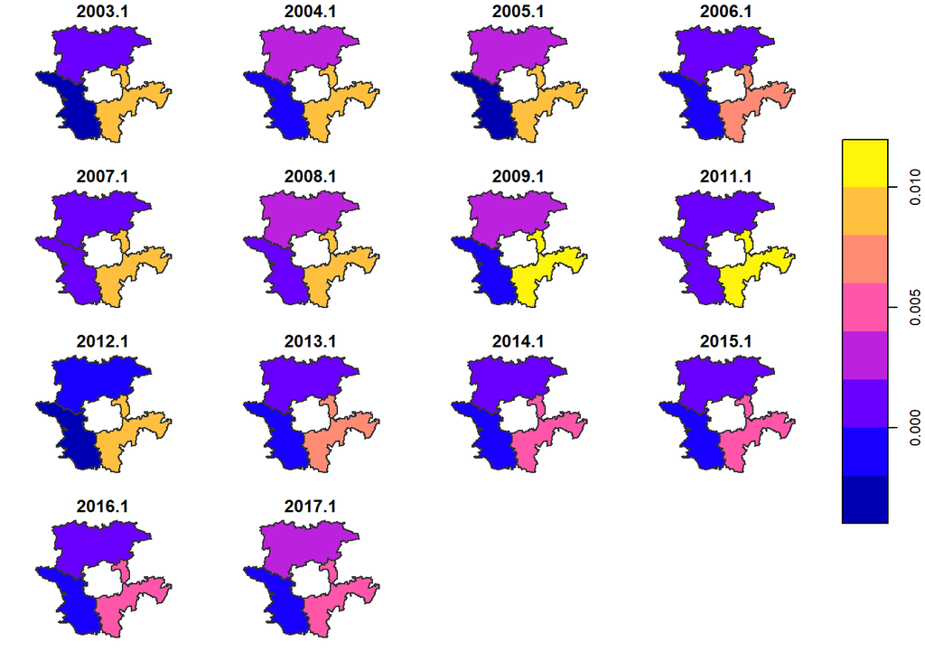

```r
plot(newSuburb2[4:17], main = "Łódź", max.plot=15, border = grey(.2), key.pos=4)
```

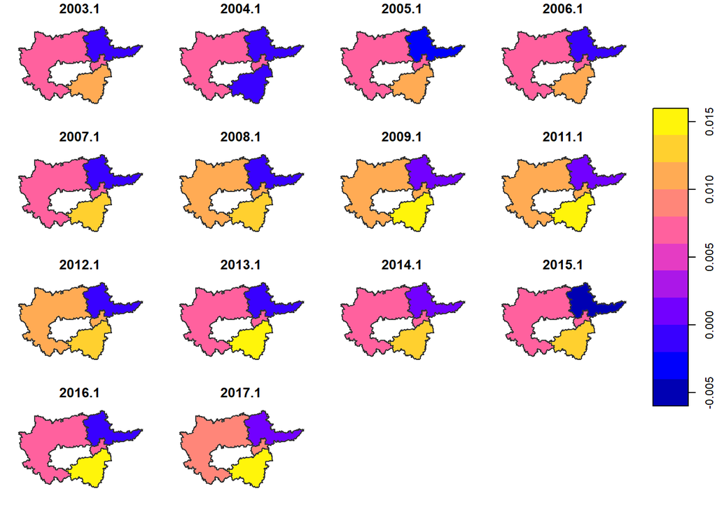

```r
plot(newSuburb3[4:17], main = "Krakow", max.plot=15, border = grey(.2), key.pos=4)
```

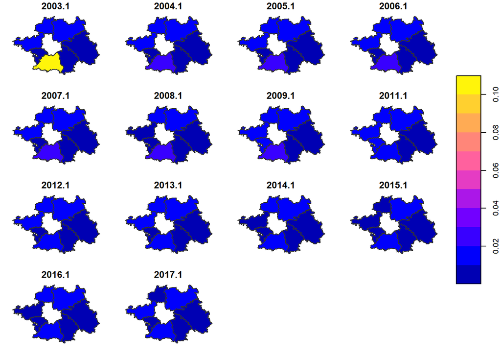

```r
plot(newSuburb4[4:17], main = "Warszawa", max.plot=15, border = grey(.2), key.pos=4)
```

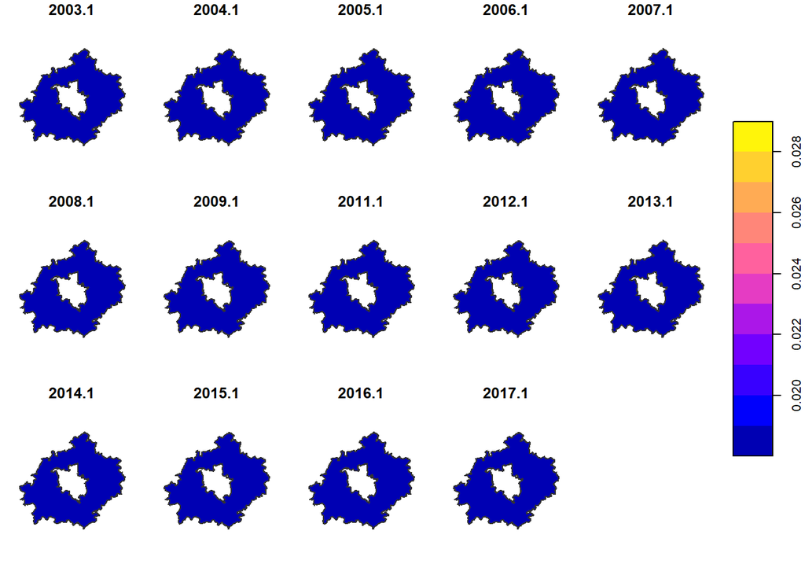

```r
plot(newSuburb5[4:17], main = "Poznań", max.plot=15, border = grey(.2), key.pos=4)
```

```r
# Extract data.frame from simple features objects and for suburbian areas
newSuburbSet_t <- newSuburbSet
st_geometry(newSuburbSet_t) <- NULL
## Create dataframe with average population increase values for all suburbs
newSuburbSet_sum <- colSums(newSuburbSet_t)
newSuburbSet_av <-newSuburbSet_sum/nrow(newSuburbSet_t)
## Create time series with average population increase values for suburbs
suburbs_av_ts <- ts(newSuburbSet_av[4:17], start = 2003, end = 2016, frequency = 1)

## Simplify and transpoze data to create ts
newSuburbSet_t["jpt_kod_je"]<-NULL
newSuburbSet_t["kod"]<-NULL
newSuburbSet_t["ID"] -> s_names
newSuburbSet_t["ID"]<-NULL
newSuburbSet_t <- as.data.frame(t(newSuburbSet_t))
### Create time-series
suburb_ts<-ts(newSuburbSet_t, start=2003, end=2016, frequency=1, names = unlist(s_names, use.names=FALSE))
```

### Population trends in main cities and suburban zones

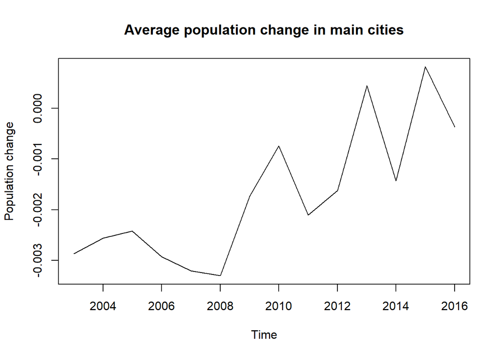

```r
plot(cities_av_ts, main="Average population change in main cities", ylab="Population change")
```

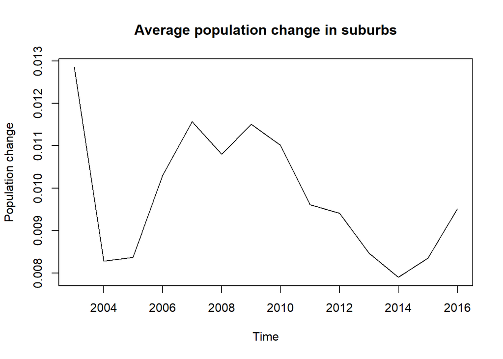

```r
plot(suburbs_av_ts, main="Average population change in suburbs", ylab="Population change")
```

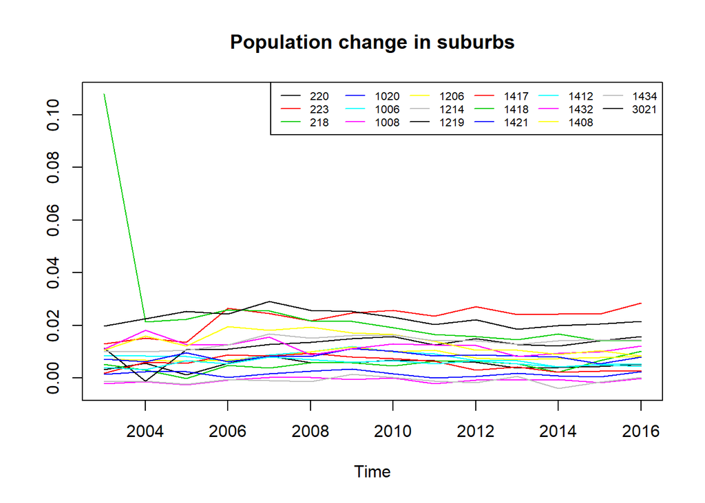

```r
ts.plot(suburb_ts, main = "Population change in suburbs", col = 1:ncol(suburb_ts))
legend("topright", colnames(suburb_ts), col = 1:ncol(suburb_ts), lty=1, cex=.65, ncol=6)
```

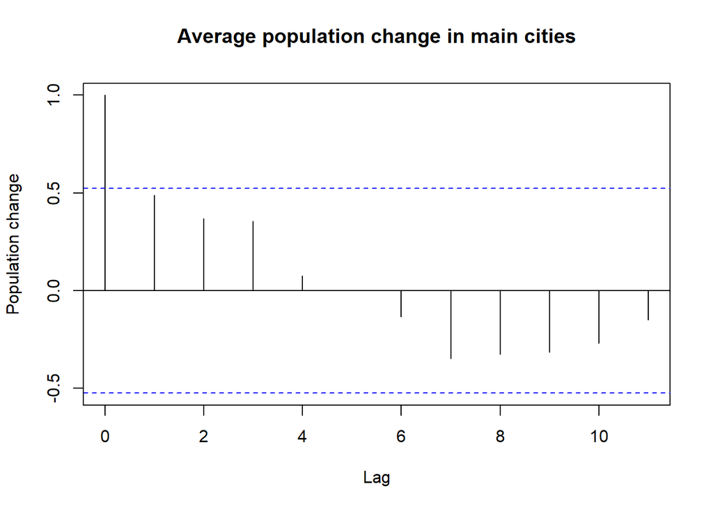

```r
acf(cities_av_ts, main="Average population change in main cities", ylab="Population change")
```

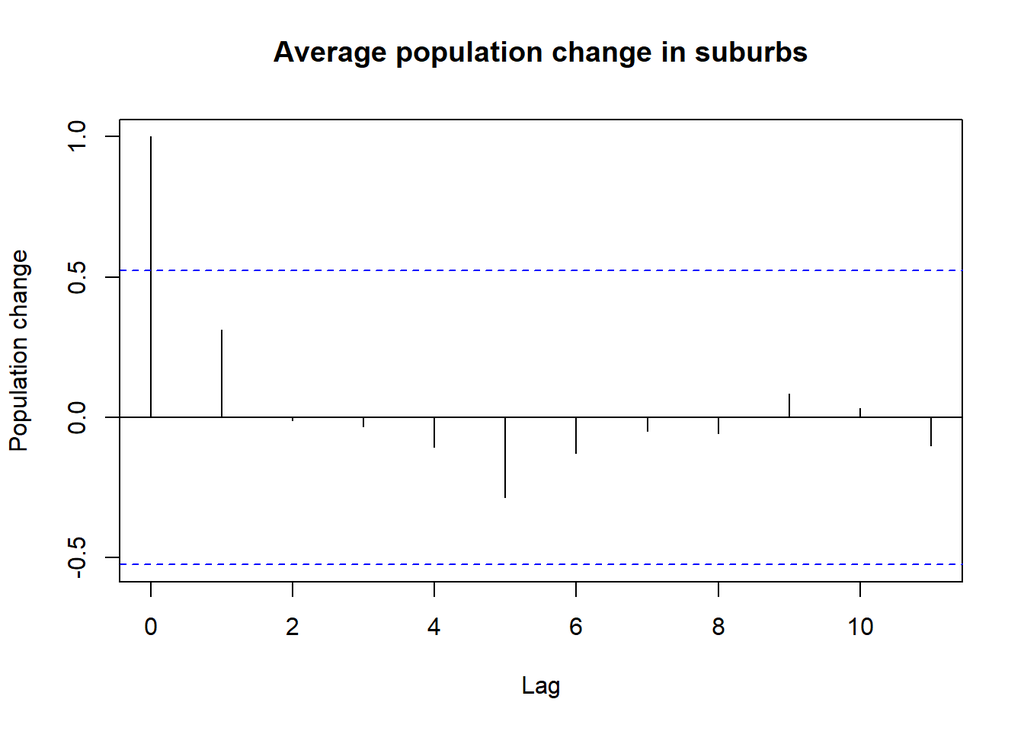

```r
acf(suburbs_av_ts, main="Average population change in suburbs", ylab="Population change")
```

The average population in cities nor in suburbian areas had no significant autocorrelation.

## Spatial correlation

### Spatial correlation of population increase in suburbian areas

For suburban counties and for the main cities the Moran I Test was executed to examine them in regard to spatial correlation.

```r
# Create centroids for suburban counties
suburbSet_c <- st_centroid(newSuburbSet)
## Save the dates for the output
d <- newSuburbSet
st_geometry(d) <- NULL
dates <- colnames(d[4:17])

# Create neighbourhood list for the suburban counties
suburbSet_1NB <- knn2nb(knearneigh(as(suburbSet_c,"Spatial"),1,FALSE))

# Create list to store Moran test output
suburb_MI <- list()

# Execute Moran I Test
for (i in 4:17) {
  suburb_MI[[i-3]] <- capture.output(moran.test(na.omit(newSuburbSet[[i]]), nb2listw(suburbSet_1NB, style="B", zero.policy=TRUE), zero.policy=TRUE))
}
```

### Spatial correlation of population increase in main cities

```r
# Create centroids for suburban counties
mainCitiesSet_c <- st_centroid(mainCitiesSet) # Return 17 points?
# Create neighbourhood list for the suburban counties
citiesSet_1NB <- knn2nb(knearneigh(as(mainCitiesSet_c,"Spatial"),1,FALSE))

# Create list to store Moran test output
cities_MI <- list()

# Execute Moran I Test
for (i in 4:17) {
  cities_MI[[i-3]] <- capture.output(moran.test(na.omit(mainCitiesSet[[i]]), nb2listw(citiesSet_1NB, style="B", zero.policy=TRUE), zero.policy=TRUE))
}
```

# Outputs

## Region comparison

Two cities were compared in this assignment: Warszawa and Łódź. They differed strongly in terms of population increase:

### Warszawa

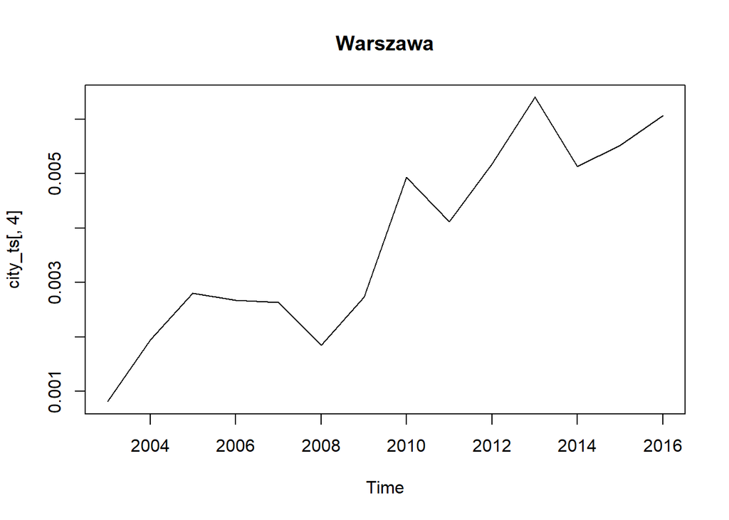

```r
ts.plot(city_ts[,4], main="Warszawa")
```

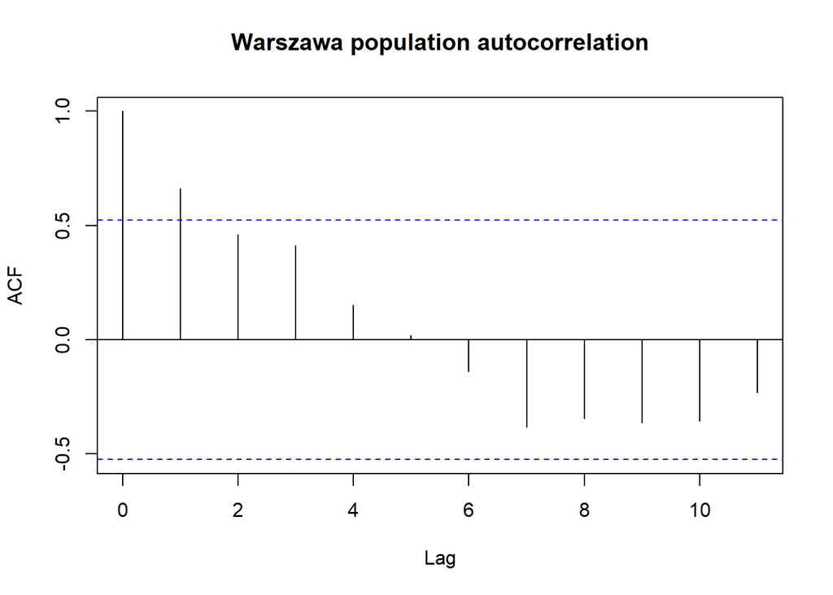

```r
acf(city_ts[,4], main= "Warszawa population autocorrelation")
```

```r
Warszawa_s <- newSuburb4
st_geometry(Warszawa_s) <- NULL
# In Warsaw 2002-2003 was excluded from the graph for the clarity
Warszawa_s_ts<-ts(t(Warszawa_s[5:17]), start=2004, end=2016, frequency = 1)
```

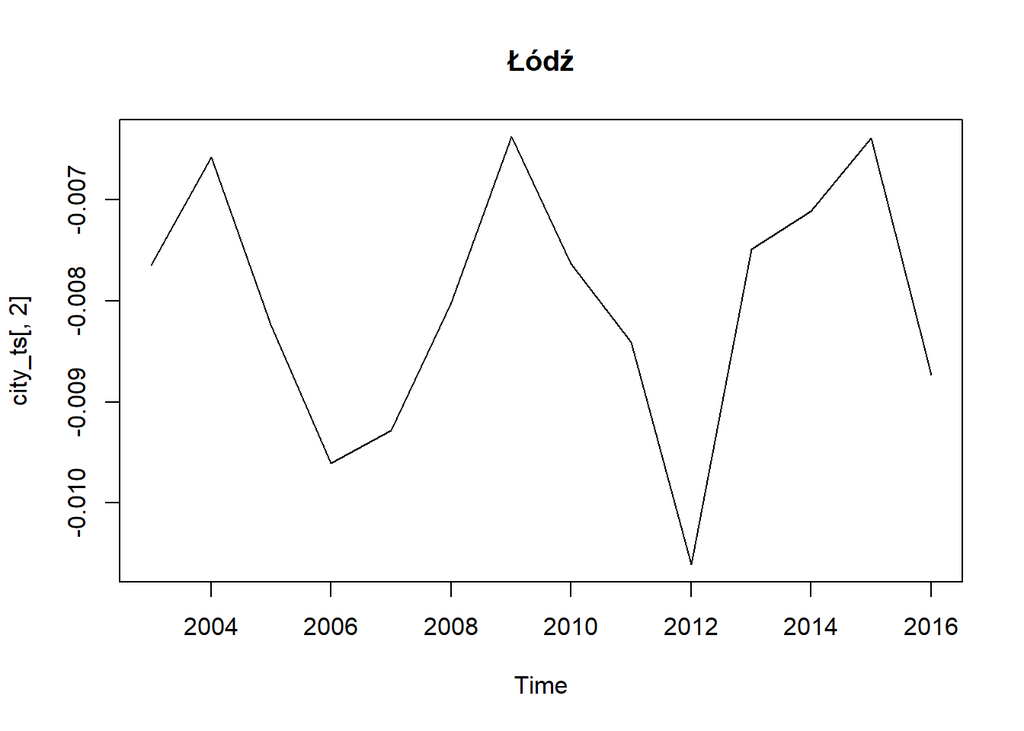

```r
ts.plot(city_ts[,2], main="Łódź")
```

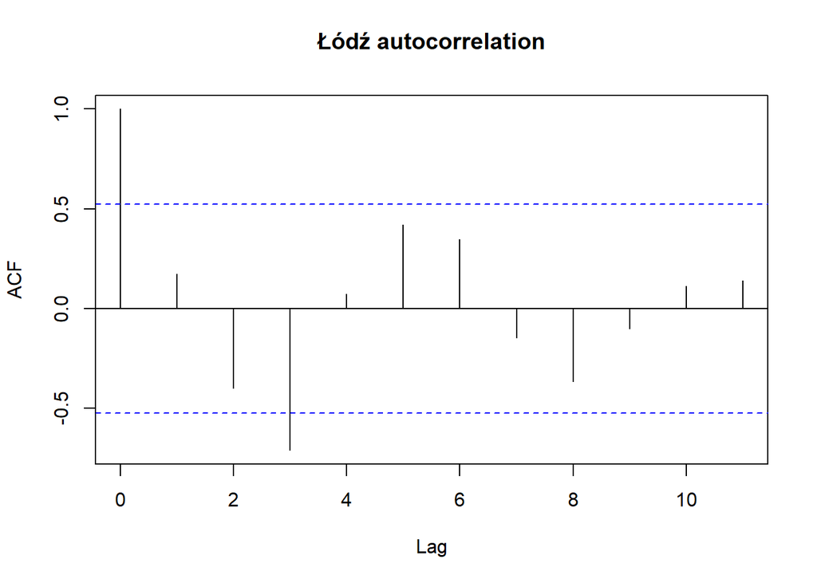

```r
acf(city_ts[,2], main="Łódź autocorrelation")
```

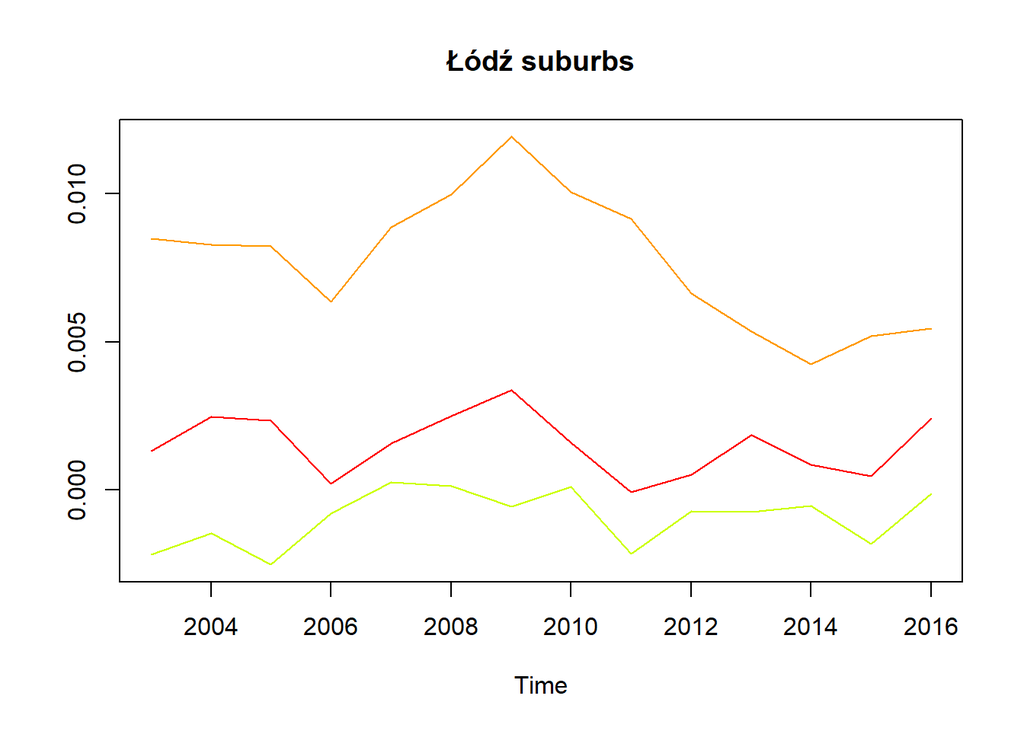

```r
Lodz_s <- newSuburb2
st_geometry(Lodz_s) <- NULL
Lodz_s_ts<-ts(t(Lodz_s[4:17]), start=2003, end=2016, frequency = 1)
ts.plot(Lodz_s_ts, main="Łódź suburbs", col=rainbow(10))
```

## Spatial correlation

Moran’s I is a correlation coefficient that measures the overall spatial autocorrelation of the data set. Moran I Test was executed for the whole country, main cities and the suburbian regions. Outputs of the test are shown in the tables:

**Poland**

```r
for (i in (1:length(Poland_MI))) {print(paste(dates[i],": ",Poland_MI[[i]][10],Poland_MI[[i]][11])) }
```

```
## [1] "2003.1 :  Moran I statistic       Expectation          Variance       -0.017147180      -0.002638522       0.003453913 "
## [1] "2004.1 :  Moran I statistic       Expectation          Variance        0.025900628      -0.002638522       0.004183479 "
## [1] "2005.1 :  Moran I statistic       Expectation          Variance       -0.042922235      -0.002638522       0.004175523 "
## [1] "2006.1 :  Moran I statistic       Expectation          Variance        0.013559792      -0.002638522       0.003586677 "
## [1] "2007.1 :  Moran I statistic       Expectation          Variance        0.011026286      -0.002638522       0.004165597 "
## [1] "2008.1 :  Moran I statistic       Expectation          Variance      -0.0005738108     -0.0026385224      0.0041778134 "
## [1] "2009.1 :  Moran I statistic       Expectation          Variance       -0.010614490      -0.002638522       0.004182700 "
## [1] "2011.1 :  Moran I statistic       Expectation          Variance        0.005493022      -0.002638522       0.004178008 "
## [1] "2012.1 :  Moran I statistic       Expectation          Variance       -0.026380302      -0.002638522       0.004189369 "
## [1] "2013.1 :  Moran I statistic       Expectation          Variance        0.005091906      -0.002638522       0.004181897 "
## [1] "2014.1 :  Moran I statistic       Expectation          Variance        0.035995866      -0.002638522       0.004184700 "
## [1] "2015.1 :  Moran I statistic       Expectation          Variance       -0.010430137      -0.002638522       0.002507601 "
## [1] "2016.1 :  Moran I statistic       Expectation          Variance       -0.043727755      -0.002638522       0.004182991 "
## [1] "2017.1 :  Moran I statistic       Expectation          Variance       -0.101855626      -0.002638522       0.003653352 "
```

For the all counties, Moran I Statistic had values close to 0, which indicate random distribution of the data. The Moran I statistics vary slightly from Expected value (-0.0026). The Variance of output is very small. This indicates that there is no spatial correlation of the data and no clustering can be observed.

**Main cities**

```r
for (i in (1:length(cities_MI))) {print(paste(dates[i],": ",cities_MI[[i]][10],cities_MI[[i]][11])) }
```

```
## [1] "2003.1 :  Moran I statistic       Expectation          Variance         -1.0049039        -0.2500000         0.3337497 "
## [1] "2004.1 :  Moran I statistic       Expectation          Variance         -0.9306623        -0.2500000         0.3495956 "
## [1] "2005.1 :  Moran I statistic       Expectation          Variance         -1.0696882        -0.2500000         0.2899109 "
## [1] "2006.1 :  Moran I statistic       Expectation          Variance         -1.0835997        -0.2500000         0.2591166 "
## [1] "2007.1 :  Moran I statistic       Expectation          Variance         -0.9739592        -0.2500000         0.3504119 "
## [1] "2008.1 :  Moran I statistic       Expectation          Variance          -1.021005         -0.250000          0.324796 "
## [1] "2009.1 :  Moran I statistic       Expectation          Variance         -1.0194829        -0.2500000         0.3714388 "
## [1] "2011.1 :  Moran I statistic       Expectation          Variance          -1.079910         -0.250000          0.291784 "
## [1] "2012.1 :  Moran I statistic       Expectation          Variance         -1.0493576        -0.2500000         0.2815786 "
## [1] "2013.1 :  Moran I statistic       Expectation          Variance         -1.0736463        -0.2500000         0.2730996 "
## [1] "2014.1 :  Moran I statistic       Expectation          Variance         -1.0667315        -0.2500000         0.3542546 "
## [1] "2015.1 :  Moran I statistic       Expectation          Variance         -0.9968568        -0.2500000         0.3504658 "
## [1] "2016.1 :  Moran I statistic       Expectation          Variance         -1.0020821        -0.2500000         0.3649241 "
## [1] "2017.1 :  Moran I statistic       Expectation          Variance         -1.0851706        -0.2500000         0.2633212 "
```

For the main cities, Moran I Statistic had values close to -1, which can indicate dispersion of the data. The Moran I statistics vary strongly from Expected value (-0.25). Morover, the Variance of output reaches values 0.2 - 0.3. This indicates that the statistic is not strongly significant.

**Suburban regions**

```r
for (i in (1:length(suburb_MI))) {print(paste(dates[i],": ",suburb_MI[[i]][10],suburb_MI[[i]][11])) }
```

```
## [1] "2003.1 :  Moran I statistic       Expectation          Variance         -0.1085590        -0.0625000         0.0113982 "
## [1] "2004.1 :  Moran I statistic       Expectation          Variance         0.10441796       -0.06250000        0.08859715 "
## [1] "2005.1 :  Moran I statistic       Expectation          Variance        -0.12976388       -0.06250000        0.08330535 "
## [1] "2006.1 :  Moran I statistic       Expectation          Variance        -0.07636412       -0.06250000        0.08720529 "
## [1] "2007.1 :  Moran I statistic       Expectation          Variance        -0.10392716       -0.06250000        0.08717047 "
## [1] "2008.1 :  Moran I statistic       Expectation          Variance        -0.07925556       -0.06250000        0.08749935 "
## [1] "2009.1 :  Moran I statistic       Expectation          Variance        -0.15244793       -0.06250000        0.08783211 "
## [1] "2011.1 :  Moran I statistic       Expectation          Variance        -0.17676359       -0.06250000        0.08776257 "
## [1] "2012.1 :  Moran I statistic       Expectation          Variance        -0.04016175       -0.06250000        0.08605452 "
## [1] "2013.1 :  Moran I statistic       Expectation          Variance        -0.15187869       -0.06250000        0.08277955 "
## [1] "2014.1 :  Moran I statistic       Expectation          Variance        -0.12439573       -0.06250000        0.08149611 "
## [1] "2015.1 :  Moran I statistic       Expectation          Variance        -0.23032848       -0.06250000        0.08510978 "
## [1] "2016.1 :  Moran I statistic       Expectation          Variance        -0.10086485       -0.06250000        0.08462473 "
## [1] "2017.1 :  Moran I statistic       Expectation          Variance        -0.03598861       -0.06250000        0.08002879 "
```

# Challenges

Two main challenges might influence the analysis output.

First of all, the population balance (population data) used for the analysis was calculated using different methodology for years before 2009 and after 2010. This might result in errors biasing the input data.

Secondly, the methodology used in the project does not give reliable results for the used sample. Moran I Test should be used on more than 30 observations and in adjacent polygons [Esri](https://pro.arcgis.com/en/pro-app/tool-reference/spatial-statistics/h-how-spatial-autocorrelation-moran-s-i-spatial-st.htm). This requirement was have been met for the analysis of all of the counties in Poland, however, not in case of the main cities and suburban zones analyses. A possible solution here would be using population data on NUTS 5 level (commune) and evaluating spatial correlation in the area of one city and the nearby units.

# Conclusions

## Summary of outputs

Outcomes of the undertaken analysis shows that population in Poland in years 2002-2017 was slowly decreasing. In the scale of the whole country it can be observed, that some reions are constantly depopulating, when in the others the number of people is constantly growing. Moran I Test perofmred for all of the counties indicates that there is no spatial correlation of the population data for the whole country.

Moran I Test gave no strongly significant results for spatial correlation of population in main cities. Moran I Test results for the suburban regions indicate the random distribution of population values.

## Tested hypothesis

Hypothesis tested in the project (H0) stated that there is no suburbanization effect taking place in the Polish counties. However, from the plots of the main cities and thei surrounding areas in period 2002-2017 we can observe, that an overall trend of decreasing the population in cities and increase in suburban can be observed. Therefore, this hypothesis needs to be rejected.

The second alternative hypothesis (H2) tested in the project stated that there can be suburbanization observed in the areas of the main Polish cities, however, not in all of them. This hypothesis was not rejected. This hypothesis is in line with the current state of the art of the suburbanization studies in Poland ([Szukalski, 2015](http://dspace.uni.lodz.pl/xmlui/bitstream/handle/11089/11164/2015-04%20Suburbanizacja.pdf?sequence=1&isAllowed=y)).

# References

- ESRI, https://pro.arcgis.com/en/pro-app/tool-reference/spatial-statistics/h-how-spatial-autocorrelation-moran-s-i-spatial-st.htm
- Komornicki T., Szejgiec-Kolenda B., Degórska B., Goch K., Śleszyński P., Bednarek-Szczepańska M., Siłka P., Spatial planning determinants of cohesion policy implementation in Polish regions. (2019), Europa XXI, in print
- Spatiotemporal Analysis, https://www.mailman.columbia.edu/research/population-health-methods/spatiotemporal-analysis
- Szukalski, P., Suburbanizacja dużych miast w Polsce, D. (2012). „Demografia i Gerontologia Społeczna–Biuletyn Informacyjny” 6. Instytut Socjologii, Uniwersytet Łódzki.
- Wikipedia, https://en.wikipedia.org/wiki/Suburbanization